# HW1

2023-01-19

## Q1

Construct a table providing summaries of the quantitative features of the dataset. Summaries should include the mean, median, minimum value, and maximum value. If you are unable to construct a formatted table within R, you can print raw output, but then comment the output to identify the answer that was requested.

```r
hw1_data %>%
  describe() %>%
  select(mean, median, min, max)
```

```
##                  mean median   min     max
## age             57.30  56.00 24.00   89.00
## bmi             27.58  27.66 18.37   38.58
## glucose         97.79  92.00 60.00  201.00
## insulin         10.01   5.92  2.43   58.46
## homa             2.69   1.38  0.47   25.05
## leptin          26.62  20.27  4.31   90.28
## adiponectin     10.18   8.35  1.66   38.04
## resistin        14.73  10.83  3.21   82.10
## mcp_1          534.65 471.32 45.84 1698.44
## classification   1.55   2.00  1.00    2.00
```

## Q2

Recode BMI into the WHO-defined categories below Severely underweight - BMI less than 16.5kg/m^2 Underweight - BMI under 18.5 kg/m^2 Normal weight - BMI greater than or equal to 18.5 to 24.9 kg/m^2 Overweight – BMI greater than or equal to 25 to 29.9 kg/m^2 Obesity class I – BMI 30 to 34.9 kg/m^2 Obesity class II – BMI 35 to 39.9 kg/m^2 Obesity class III – BMI greater than or equal to 40 kg/m^2

```r
hw1_data = hw1_data %>%
  mutate(bmi = round(bmi, digits = 1)) %>%
  mutate(bmi_class = case_when(bmi <16.4 ~ "severely underweight",
          bmi <= 18.4 ~ "underweight",
          bmi <= 24.9 ~ "normal weight",
          bmi <= 29.9 ~ "overweight",
          bmi <= 34.9 ~ "obesity class I",
          bmi <= 39.9 ~ "obesity class II",
          bmi >= 40 ~ "obesity class III"))
```

- New variable “bmi_class” was created to indicate the BMI categories.

## Q3

Create a bar chart showing the proportion of breast cancer cases and controls within each BMI category. ( That is, the graph should clearly show, what % of each BMI category are cases and what % are controls)

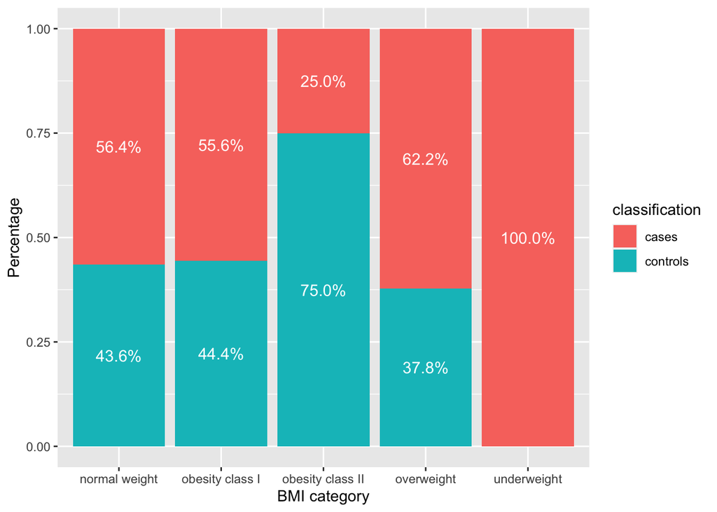

```r
plot_data = hw1_data %>%
  mutate(classification = ifelse(classification == 1, "controls", "cases")) %>%
  group_by(bmi_class, classification) %>%
  tally() %>%
  mutate(percent = n/sum(n))

bar_chart = plot_data %>%
  ggplot(aes(x = bmi_class, y = n, fill = classification)) +
  geom_bar(stat = "identity", position = "fill") +
  geom_text(aes(label = paste0(sprintf("%1.1f", percent*100),"%")),
            position = position_fill(vjust = 0.5), colour = "white", size = 4) +
  labs(x = "BMI category", y = "Percentage")

bar_chart
```

## Q4

Construct a logistic regression model using breast cancer classification as the outcome and glucose, HOMA-IR, leptin, BMI (continuous) and age as the independent variables. Fill in the beta estimate and 95% confidence interval associated with a 1-unit change in HOMA-IR

```r
hw1_data = hw1_data %>%
  mutate(classification = ifelse(classification == 1, 0,1)) %>%
  mutate(classification = as.numeric(classification))

logit = glm(classification ~ glucose + homa + leptin + bmi + age, data = hw1_data, family = "binomial")
cbind(beta = coef(logit), confint(logit))
```

```
##                     beta       2.5 %      97.5 %
## (Intercept) -3.616172680 -8.53406749 0.766396563
## glucose      0.081677577  0.03955362 0.132370810
## homa         0.273851691 -0.02563361 0.653183739
## leptin      -0.008545135 -0.04016880 0.022451561
## bmi         -0.104472335 -0.21971267 0.004246162
## age         -0.022929889 -0.05197999 0.004812515
```

## Q5

Construct a linear regression model using insulin as the outcome and BMI (continuous), age, and glucose as the independent variables. Fill in the beta estimate and 95% confidence interval associated with a 1-unit change in age.

```r
linear = lm(insulin ~ bmi + age + glucose, data = hw1_data)

cbind(beta = coef(linear), confint(linear))
```

```
##                     beta       2.5 %      97.5 %
## (Intercept) -13.48128742 -25.0983180 -1.86425686
## bmi           0.14900623  -0.1757673  0.47377974
## age          -0.05398618  -0.1569028  0.04893041
## glucose       0.22984107   0.1555063  0.30417584
```